# Predicting the Best Places in London to Open a New Restaurant

## 4. Results

Now, I'm going to plot all the restaurants on the map of London with blue markers, with the boroughs displayed in red.

```python
map_london = folium.Map(location=[latitude, longitude], zoom_start=10)

for lat, lng, venue in zip(london_restaurants['Venue Latitude'], london_restaurants['Venue Longitude'], london_restaurants['Venue']):
    label = '{}'.format(venue)
    label = folium.Popup(label, parse_html=True)
    folium.CircleMarker(
        [lat, lng],
        radius=5,
        popup=label,
        color='blue',
        fill=True,
        fill_color='#3186cc',
        fill_opacity=0.7,
        parse_html=False).add_to(map_london)

for lat, lng, borough in zip(final_df['Latitude'], final_df['Longitude'], final_df['Borough']):
    label = '{}'.format(borough)
    label = folium.Popup(label, parse_html=True)
    folium.CircleMarker(
        [lat, lng],
        radius=5,
        popup=label,
        color='red',
        fill=True,
        fill_color='#3186cc',
        fill_opacity=0.7,
        parse_html=False).add_to(map_london)

map_london
```

[interactive chart not shown]

I'm now going to look at the distribution of "Venue Category" for each Borough and see if there is anything significant about that.

```python
london_restaurants.groupby(['Borough','Venue Category']).size()
```

```
Borough                  Venue Category
Barnet                   Café                               2
Bexley                   Chinese Restaurant                 1
                         Fast Food Restaurant               2
                         Italian Restaurant                 2
                         Portuguese Restaurant              1
                         Sandwich Place                     1
Brent                    American Restaurant                3
                         Asian Restaurant                   1
                         Brazilian Restaurant               1
                         Burger Joint                       1
                         Café                               1
                         Fast Food Restaurant               2
                         Indian Restaurant                  2
                         Italian Restaurant                 3
                         Latin American Restaurant          1
                         Pizza Place                        1
                         Portuguese Restaurant              1
                         Restaurant                         1
                         Sandwich Place                     3
                         Seafood Restaurant                 1
Bromley                  Asian Restaurant                   1
                         Burger Joint                       2
                         Burrito Place                      1
                         Café                               1
                         English Restaurant                 1
                         Pizza Place                        2
                         Portuguese Restaurant              1
                         Sandwich Place                     1
                         Sushi Restaurant                   1
                         Turkish Restaurant                 1
Camden                   BBQ Joint                          1
                         Breakfast Spot                     2
                         Burger Joint                       3
                         Café                               6
                         English Restaurant                 1
                         Falafel Restaurant                 1
                         Greek Restaurant                   1
                         Indian Restaurant                  1
                         Italian Restaurant                 2
```

[output cut: 328 more lines]

```
                         Falafel Restaurant                 1
                         Fast Food Restaurant               1
                         Indian Restaurant                  1
                         Italian Restaurant                 3
                         Korean Restaurant                  1
                         Modern European Restaurant         1
                         Pizza Place                        1
                         Poke Place                         1
                         Restaurant                         2
                         Salad Place                        1
                         Sandwich Place                     9
                         Scandinavian Restaurant            1
                         Sushi Restaurant                   3
                         Thai Restaurant                    1
dtype: int64
```

[output not shown]

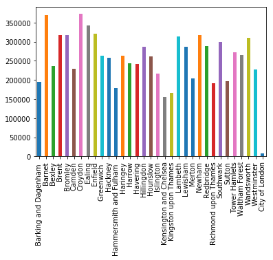

```python
barplot = final_df['Population'].astype(str).astype(int).plot(kind = 'bar').set_xticklabels(final_df['Borough'])
barplot
```

Based on the populations barplot, we see that the boroughs with the 3 highest populations are Croydon, Barnet, and Ealing. Looking at the types of restaurants for these three boroughs, we see that Barnet only has two Cafés, and Ealing has quite a large number *and* large variety of restaurants already.

## 5. Conclusion

The restaurants in Croydon all have unique cuisines, and there is a moderate number of them compared to those of other regions. Opening a restaurant in Croydon with a unique cuisine that would not compete with the restaurants already there, but is possibly successful in other boroughs, may be a good approach. For example, restaurants with category "Sandwich Place" seem relatively common in other boroughs, but there is none in the dataset for Croydon.

Therefore, I would suggest opening a sandwich restaurant in Croydon, since that type of restaurant would be unique to the area and contribute greatly to the variety of its restaurant culture.